# Analyzing DAO Voting Topology

2022-06-23

# Background and Motivation

Perhaps the dominant ideological impulse of the internet era is a broad and variously-described campaign for “decentralization.” Calls for decentralization spurred the development of the early internet; more recently, they form the driving rhetorical impetus to the blockchain and Web3 movements. Though various definitions [1] [2] [3] and taxonomies [4] [5] [6] of decentralization have been offered, the notion’s ambiguity constitutes a major theoretical crux in the academic study of modern, especially digitally-enabled, organizations.

At the [Metagovernance Project](https://metagov.org/), we seek to shed light on modern problems of social coordination using the framework of *governance*. This article is a preliminary effort to explore the problem of decentralization–its motivations, representations, and potential effects–from the perspective of governance. Ultimately, it is part of a push to establish an expressive formal language for researchers grappling with the extremely difficult, increasingly complex, and all-too-salient problems presented by 21st-century collective action.

# The Voting Perspective

Decentralization is alleged to be beneficial for a variety of reasons. The blockchain community has historically focused on things like security, integrity, and resilience–resistance to attacks and collusion, avoidance of single points of failure, prevention of authoritarianism, etcetera [5]. For this reason, most past studies of decentralization in blockchains have defined decentralization in a technical sense (e.g., network measures on the underlying nodes [7]), or with an eye to security (e.g., how many entities it would take to execute a 51% attack [8]). These measures are not the focus of this analysis, but a recent DARPA-commissioned report summarizes the general evidence that the Web3 ecosystem has not, thus far, been very successful in achieving these goals [9].

We’re interested in sociopolitical arrangements within a general class organizations, so for us, “decentralization” has much to do with distribution of power between individuals. While power over the underlying infrastructure–the type of power wielded by validators, for example–is an example of this, we ultimately want “substrate-independent” measures of power distribution. The easy, well-defined starting point for this analysis is *voting power*. Voting is far from the whole story of governance, but it is an important source of hard power within a democratic system. Additionally, analyzing voting data could help illuminate less visible governance factors like social influence, agenda-setting power [10], and ideological or cultural topology.

# Data

Decentralized Autonomous Organizations are a good subject of governance study due to their diversity and openness to experimentation. They also care (a lot) about decentralization and effective governance. For this analysis I used voting data from [Snapshot](https://snapshot.org/#/), a popular off-chain voting platform. In particular, I gathered a dataset of votes from the [Proof-of-Humanity snapshot](https://snapshot.org/#/poh.eth) (see the code used to gather this dataset [here](https://github.com/tobyweed/voting_games/blob/master/voting_data.Rmd)).

```r
votes <- read.csv("votes.csv", colClasses = c("Voter.ID" = "character")) # Voter.ID will be read as a hex number if type is unspecified
```

**Note:** I chose Proof of Humanity because they have relatively few active voters, and their votes tend to be relatively controversial, while many DAO votes are more or less unanimous. However, voting data could be gathered from any DAO on Snapshot within a couple of minutes using the same code.

I chose to focus on the seven most recent proposals with binary voting, for the reason that these have highly-overlapping voter pools. This will make our clustering analysis later on more meaningful. However, one can easily imagine analyzing more proposals.

This leaves us with a very manageable set of 69 voters and 7 proposals.

# Analysis

To start off, we’ll organize our data into a table with individual voters as the rows, proposals as the columns, and cells corresponding to voters’ choices.

```r
vot_tab
```

```
##     1  2  3  4  5  6  7
## 1   1 NA  1  1  1  1 NA
## 2   2  1  2  1 NA NA NA
## 3   1  1  1  1 NA  1  2
## 4   1 NA  1  1 NA NA  2
## 5   1 NA  1  1 NA NA  2
## 6   2 NA  1  1  1  1  2
## 7   1  1  1  1 NA NA  1
## 8   1 NA  1 NA  1  1 NA
## 9   1  1  1 NA NA NA  2
## 10  2  2 NA  1 NA  1 NA
## 11  1  1  1 NA  1  1 NA
## 12  1  1  1  1 NA NA NA
## 13  1 NA NA  1  1  1 NA
## 14  1  1  1  1 NA NA NA
```

[output cut: 55 more lines]

How should we analyze decentralization in this voting system? Traditional political science models of voting power include the [Shapley-Shubik](https://en.wikipedia.org/wiki/Shapley%E2%80%93Shubik_power_index#:~:text=The%20Shapley%E2%80%93Shubik%20power%20index,not%20obvious%20on%20the%20surface.) and [Banzhaf](https://en.wikipedia.org/wiki/Banzhaf_power_index) indices, which both measure (in different ways) the likelihood that a coalition swings the vote in any given way. One simple idea would be to take a look at the distribution of “voting power,” variously defined, among different entities within a system.

Of course, this brings up the question of how we’d like to define “entities” in the DAO context. This question is actually more interesting than it might appear at first glance; the analogy with traditional democratic assemblies (e.g. within nation-states) tells us that groups of individuals often self-organize into coalitions which generally operate as a unit. One important and interesting governance question, then, is to what extent do individuals within an organization form discrete coalitions? Posed more holistically, what is the topology of *preferences* within the voting body?

```r
# how many missing values do we have?
na_counts <- rowSums(is.na(vot_tab))
table(na_counts)
```

```
## na_counts
##  0  1  2  3
##  6 16 15 32
```

```r
mean(na_counts)
```

```
## [1] 2.057971
```

Six voters voted on every proposal, 22 missed at most one, and 37 missed at most two. The average voter in our set missed about two of the seven votes we’re looking at. This is not too sparse a dataset (by design), so we’ll go ahead and measure the similarity between each voter’s voting record. We’d like the distance between two voters to be the sum of the distance between their votes on each proposal, i.e. $d(\vec{x}, \vec{y}) = \sum_i d(x_i,y_i)$. We also might want `NA` votes (abstensions) to be halfway between a “yes” and a “no.” This corresponds to using the [Manhattan metric](https://en.wikipedia.org/wiki/Taxicab_geometry) and replacing `NA` values with `1.5`, since the voting options are `1` and `2`.

```r
vot_tab[is.na(vot_tab)] <- 1.5
dist <- dist(vot_tab, method = "manhattan")
dist_mat <- as.matrix(dist)
```

Now, we can represent the voting similarities as a weighted graph.

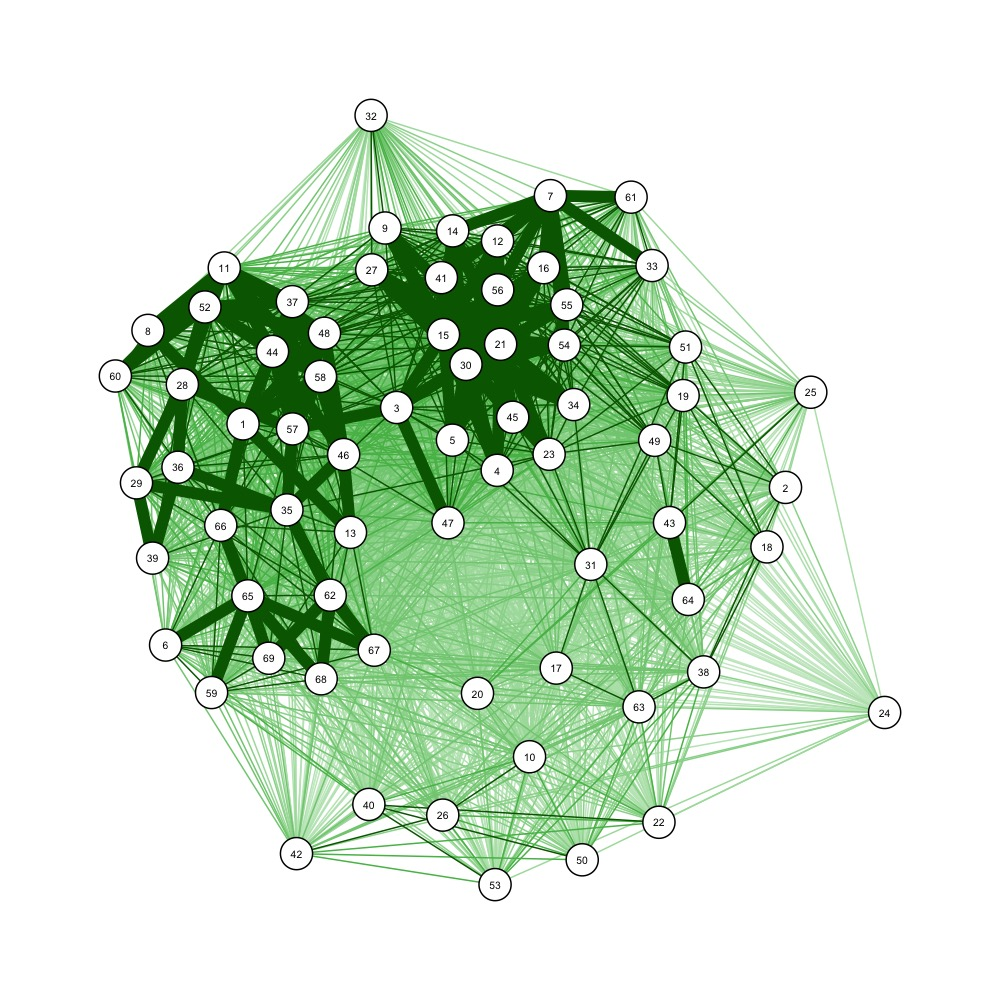

It looks like there are at least a couple of pretty densely-connected clusters of similar voters. Down the line, this kind of representation could play a role in a more general analysis of ideological affiliation, which could tell us things about cohesion, polarization, and so on.

**Note 1:** one can easily imagine defining a multilayer network by bringing in data from other DAOs, since addresses often hold voting tokens in multiple DAOs. This would allow a more general analysis of preference topology and voting influence within the broader DAO ecosystem, which could be pretty interesting.

**Note 2:** it might also be interesting to quantify the “preference centralization” or “polarization” within our voting graph using graph-based measures of clustering, decentralization, and so on (closeness centrality, degree centrality, Freeman centralization, local clustering coefficient, global clustering coefficient, etc.).

In order to get a rough power distribution, we can define “coalitions” or “voting blocs” by hierarchically clustering on this graph.

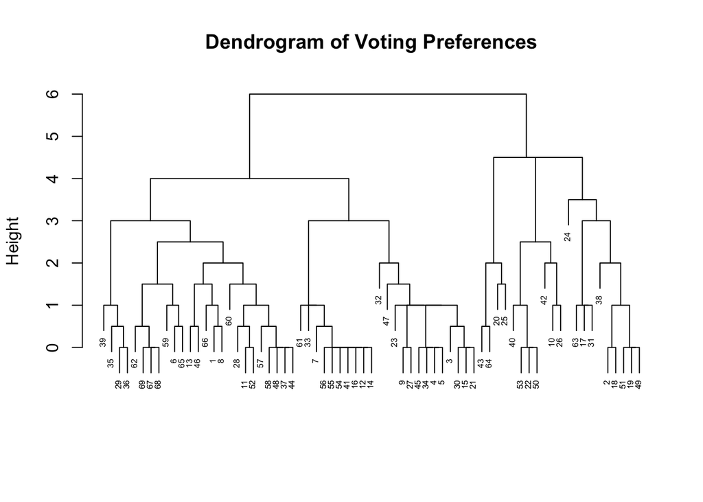

```r
hc <- hclust(dist, method = "complete")
plot(hc, main = "Dendrogram of Voting Preferences", xlab = "", sub = "",
     cex = 0.5)
```

Let’s define 5 coalitions, just cause.

**Note:** I’m choosing complete linkage clustering and a number of clusters/threshold for voting agreement within coalitions pretty arbitrarily. One can imagine only defining coalitions which agree completely, or which correspond to prior knowledge of actual actors within a system. Nonetheless, I think it’s an interesting exercise.

```r
# Cluster the voters into voting "blocs"
hc_clusters <- cutree(hc, 5)
```

```r
hc_clusters
```

```
##  1  2  3  4  5  6  7  8  9 10 11 12 13 14 15 16 17 18 19 20 21 22 23 24 25 26
##  1  2  3  3  3  1  3  1  3  4  1  3  1  3  3  3  2  2  2  5  3  4  3  2  5  4
## 27 28 29 30 31 32 33 34 35 36 37 38 39 40 41 42 43 44 45 46 47 48 49 50 51 52
##  3  1  1  3  2  3  3  3  1  1  1  2  1  4  3  4  5  1  3  1  3  1  2  4  2  1
## 53 54 55 56 57 58 59 60 61 62 63 64 65 66 67 68 69
##  4  3  3  3  1  1  1  1  3  1  2  5  1  1  1  1  1
```

**Note:** It’d be fun to redraw the voting graph, coloring nodes by the clusters they belong to and maybe adjusting their size by their voting weight.

So, given these voting blocs, what’s the distribution of voting tokens?

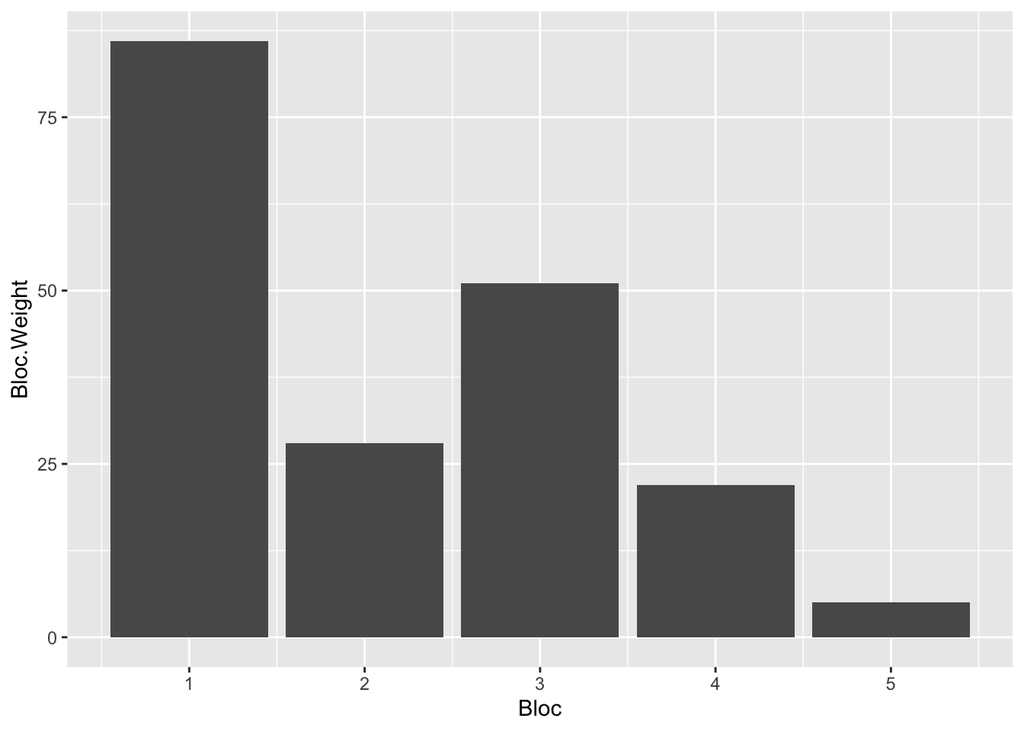

```r
bloc_dist %>% ggplot(aes(x = Bloc, y = Bloc.Weight)) +
  geom_col()
```

We can measure the “voting token wealth inequality” by Gini coefficient:

```r
gini(bloc_dist$Bloc.Weight)
```

```
## [1] 0.3979167
```

or the voting power distribution by Shapley-Shubik index:

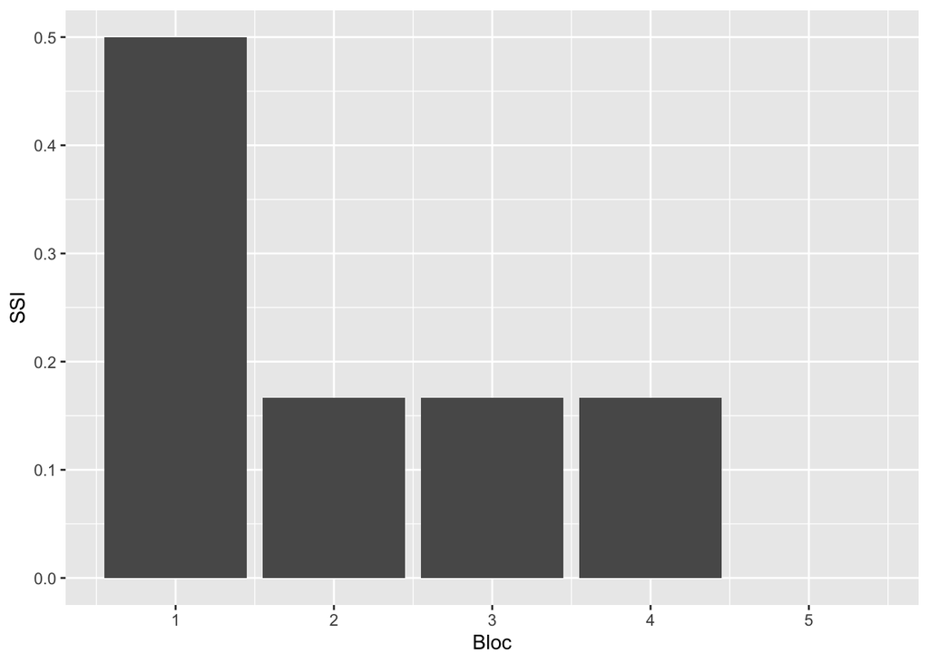

```r
bloc_dist %>% ggplot(aes(x = Bloc, y = SSI)) +
  geom_col()
```

# Conclusion

This is obviously an incomplete draft, and much of the “analysis” is very arbitrary. That said, I think it shows that there’s some interesting insight to be drawn *just* from analyzing voting data in DAOs. The notes throughout show directions one could go, either by including more diverse data, considering different representations, engaging in more rigorous justification, or probing the analysis with different visualizations and metrics.

In terms of the future direction of the decentralization metrics project, I do think that we’ll get a lot of value by looking at more holistic data than just voting records. That being said, I think that the voting perspective has the advantage of being really easy to analyze, and could shed light on more subtle dynamics (and might inspire interesting DAO representations, which I guess is what we’re really after). At the very least I think another couple weeks here could produce a solid blog post.

# References

[1]

S. Hassan and P. D. Filippi, “Decentralized autonomous organization,” *Internet Policy Review*, vol. 10, no. 2, Apr. 2021, doi: 10.14763/2021.2.1556.

[2]

D. R. Dalton, W. D. Todor, M. J. Spendolini, G. J. Fielding, and L. W. Porter, “Organization structure and performance: A critical review,” *The Academy of Management Review*, vol. 5, no. 1, p. 49, Jan. 1980, doi: 10.2307/257804.

[3]

M. Rauchs *et al.*, *[Distributed ledger technology systems: A conceptual framework](https://EconPapers.repec.org/RePEc:jbs:altfin:201810-dlts)*. Cambridge Centre for Alternative Finance, Cambridge Judge Business School, University of Cambridge, 2018.

[4]

A. R. Sai, J. Buckley, B. Fitzgerald, and A. L. Gear, “Taxonomy of centralization in public blockchain systems: A systematic literature review,” *Information Processing and Management*, vol. 58, no. 4, p. 102584, Jul. 2021, doi: 10.1016/j.ipm.2021.102584.

[5]

V. Buterin, “The meaning of decentralization,” *Medium*. Medium, Feb. 2017, [Online]. Available: https://medium.com/@VitalikButerin/the-meaning-of-decentralization-a0c92b76a274.

[6]

D. Siddarth, D. Allen, and E. G. Weyl, “The Web3 decentralization debate is focused on the wrong question,” *Wired*. May 2022, [Online]. Available: https://www.wired.com/story/web3-blockchain-decentralization-governance/.

[7]

Y. Shahsavari, K. Zhang, and C. Talhi, “Toward quantifying decentralization of blockchain networks with relay nodes,” *Frontiers in Blockchain*, vol. 5, Feb. 2022, doi: 10.3389/fbloc.2022.812957.

[8]

B. S. Srinivasan, “Quantifying decentralization,” *Medium*. news.earn.com, Oct. 2017, [Online]. Available: https://news.earn.com/quantifying-decentralization-e39db233c28e.

[9]

E. Sultanik *et al.*, “Are blockchains decentralized? Unintended centralities in distributed ledgers,” 2022, [Online]. Available: https://assets-global.website-files.com/5fd11235b3950c2c1a3b6df4/62af6c641a672b3329b9a480_Unintended_Centralities_in_Distributed_Ledgers.pdf.

[10]

E. L. Rossiter, “Measuring agenda setting in interactive political communication,” *American Journal of Political Science*, vol. 66, no. 2, pp. 337–351, Sep. 2021, doi: 10.1111/ajps.12653.